# Beautiful plots made via myTAI

## Gallery of different plots available with myTAI

Here are example outputs of plotting functions from `myTAIv2`.

We hope these plots can inspire your analysis!

### Bulk RNA-seq data

`example_phyex_set` is an example `BulkPhyloExpressionSet` object.

To learn more about bringing your dataset into myTAI, follow this vignette here:  
→ 📊

```r
library(myTAI); library(S7); library(ggplot2); library(patchwork)
data("example_phyex_set")
```

#### myTAI plots can be modified as a ggplot2 object.

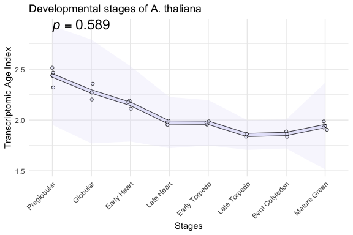

```r
myTAI::plot_signature(example_phyex_set,
                      show_p_val = TRUE,
                      conservation_test = stat_flatline_test,
                      colour = "lavender") +
  # as the plots are ggplot2 objects, we can simply modify them using ggplot2
  ggplot2::labs(title = "Developmental stages of A. thaliana")
```

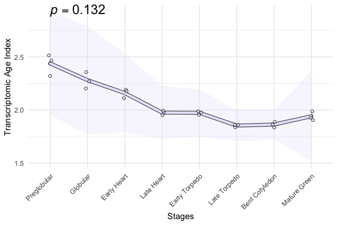

```r
module_info <- list(early = 1:3, mid = 4:6, late = 7:8)
myTAI::plot_signature(example_phyex_set,
                      show_p_val = TRUE,
                      conservation_test = stat_reductive_hourglass_test,
                      modules = module_info,
                      colour = "lavender")
```

#### Transformation and robustness checks

See more here:  
→ 🛡️

```
## Computing: [========================================] 100% (done)
## Computing: [========================================] 100% (done)
## Computing: [========================================] 100% (done)
## Computing: [========================================] 100% (done)
## Computing: [========================================] 100% (done)
```

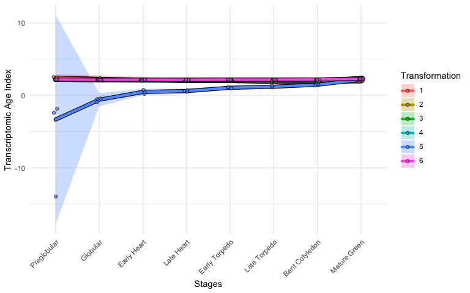

```r
myTAI::plot_signature_transformed(
  example_phyex_set)
```

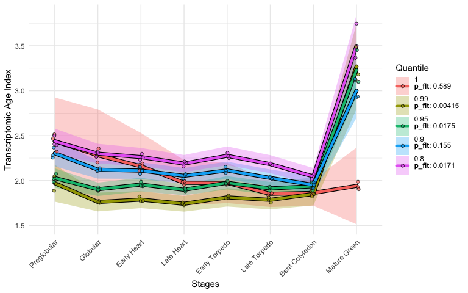

```r
myTAI::plot_signature_gene_quantiles(
  example_phyex_set)
```

#### Statistical tests and plotting results

See more here:  
→ 📈

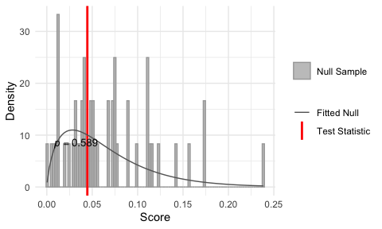

```
##
## Statistical Test Result
## =======================
## Method: Flat Line Test
## Test statistic: 0.0446168
## P-value: 0.589021
## Alternative hypothesis: greater
## Data: Embryogenesis 2019
```

```r
myTAI::stat_flatline_test(
  example_phyex_set, plot_result = TRUE)
```

```r
res_flt <- myTAI::stat_flatline_test(example_phyex_set, plot_result = FALSE)
```

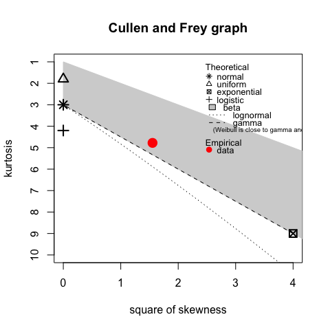

```
## summary statistics
## ------
## min:  0.0003722363   max:  0.2384254
## median:  0.05142977
## mean:  0.06597962
## estimated sd:  0.05034775
## estimated skewness:  1.246251
## estimated kurtosis:  4.777075
```

```r
myTAI::plot_cullen_frey(res_flt)
```

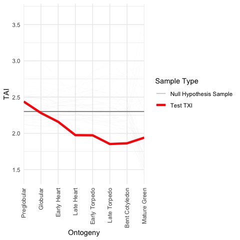

```r
myTAI::plot_null_txi_sample(res_flt) +
  ggplot2::guides(x =  guide_axis(angle = 90))
```

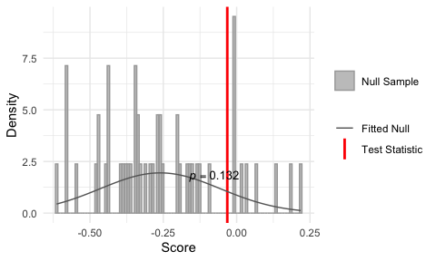

```
##
## Statistical Test Result
## =======================
## Method: Reductive Hourglass Test
## Test statistic: -0.03191036
## P-value: 0.1323464
## Alternative hypothesis: greater
## Data: Embryogenesis 2019
```

```r
module_info <- list(early = 1:3, mid = 4:6, late = 7:8)
myTAI::stat_reductive_hourglass_test(
  example_phyex_set, plot_result = TRUE,
  modules = module_info)
```

#### Average gene expression level by phylostratum

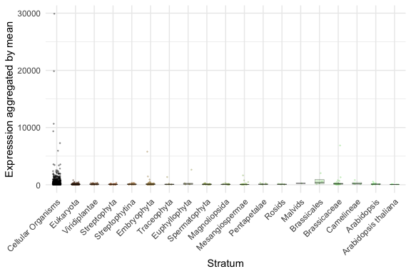

```r
myTAI::plot_strata_expression(example_phyex_set)
```

`plot_strata_expression` with scaled y axis

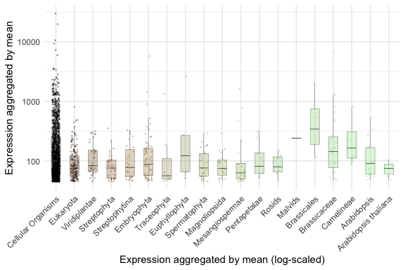

```r
myTAI::plot_strata_expression(example_phyex_set) +
  ggplot2::scale_y_log10() +
  ggplot2::labs(x = "Expression aggregated by mean (log-scaled)")
```

`plot_strata_expression` with explicit transformation

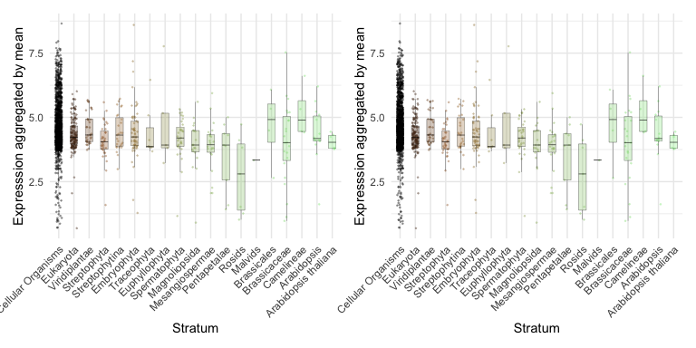

```r
library(patchwork)
p1 <- myTAI::plot_strata_expression(example_phyex_set |> myTAI::tf(log1p))

# equivalent to
p2 <- example_phyex_set |> myTAI::tf(log1p) |> myTAI::plot_strata_expression()

p1+p2
```

As you can see, both plots are identical. This example demonstrates that there are multiple ways to achieve the same result through piping (`|>`) operator in R. `|>` is basically the same as `%>%`.

#### Contribution to the overall TAI by phylostratum

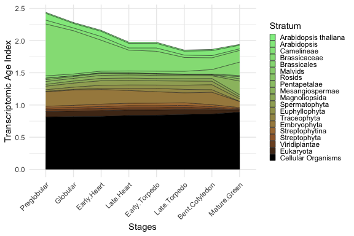

```r
myTAI::plot_contribution(example_phyex_set)
```

Curious about methods to obtain gene age information? See more here:  
→ 📚

For other analogous methods to assign evolutionary or expression information to each gene for TDI, TSI etc., see here:  
→ 🧬

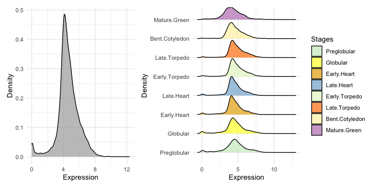

```r
myTAI::plot_distribution_expression(example_phyex_set)
```

#### Contribution to the overall TAI by partial TAI (pTAI)

`pTAI`, or

$$\mathrm{pTAI}_i = \frac{\mathrm{ps}_i \cdot e_{is}}{\sum_{i=1}^{n}
e_{is}}$$

where $e_{is}$ denotes the expression level of a given gene $) i$ in sample $s$, ${ps}_i$ is its gene age assignment, and $n$ is the total number of genes, is the per-gene contribution to the overall `TAI`. (Summing `pTAI` across all genes gives in a given sample $s$ gives the overall ${TAI}_s$ )

`pTAI` QQ plot compares the partial TAI distributions of various developmental stages against a reference stage (default is stage 1).

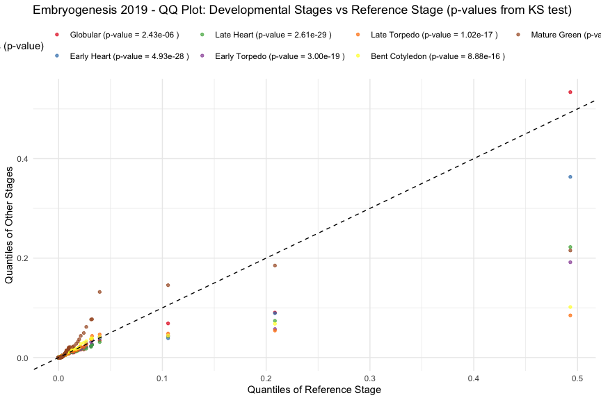

```r
myTAI::plot_distribution_pTAI_qqplot(example_phyex_set)
```

#### Phylostratum distribution

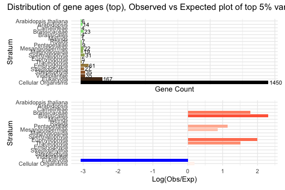

```r
myTAI::plot_distribution_strata(example_phyex_set@strata) /
myTAI::plot_distribution_strata(
  example_phyex_set@strata,
  selected_gene_ids = myTAI::genes_top_variance(example_phyex_set, top_p = 0.95),
  as_log_obs_exp = TRUE
) + plot_annotation(title = "Distribution of gene ages (top), Observed vs Expected plot of top 5% variance genes (bottom)")
```

#### Expression heatmap

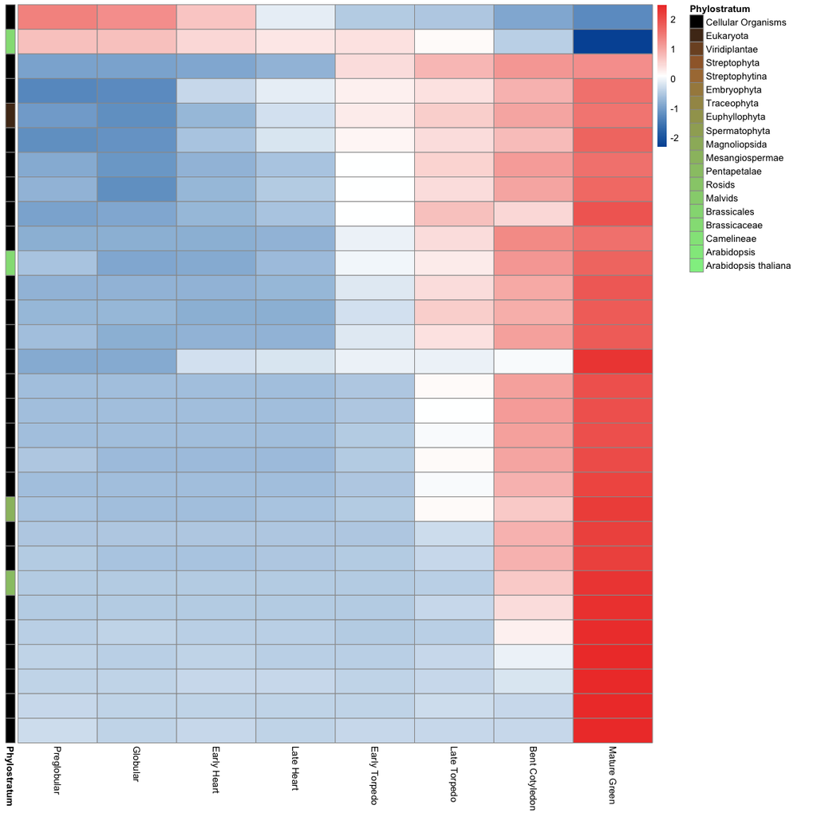

```r
myTAI::plot_gene_heatmap(example_phyex_set)
```

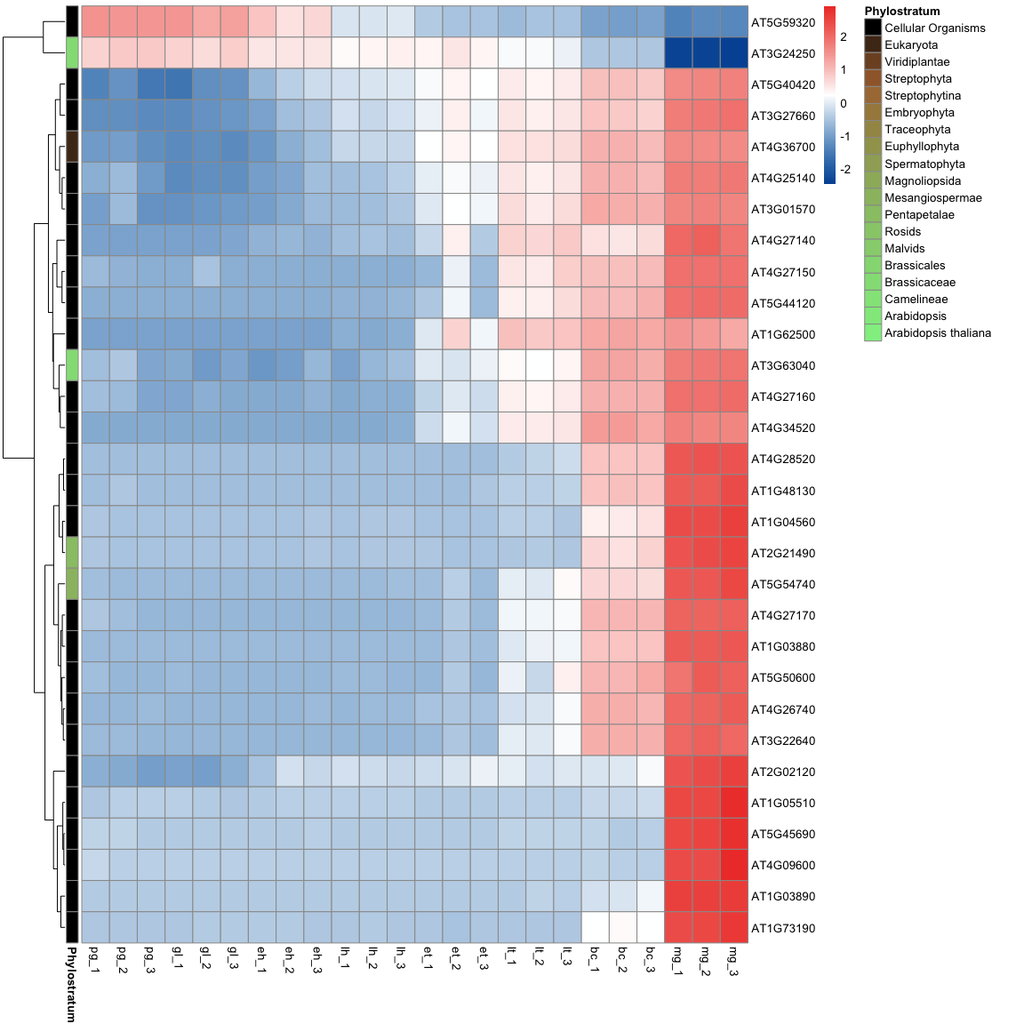

```r
myTAI::plot_gene_heatmap(example_phyex_set, cluster_rows = TRUE, show_reps=TRUE, show_gene_ids=TRUE, top_p=0.005)
```

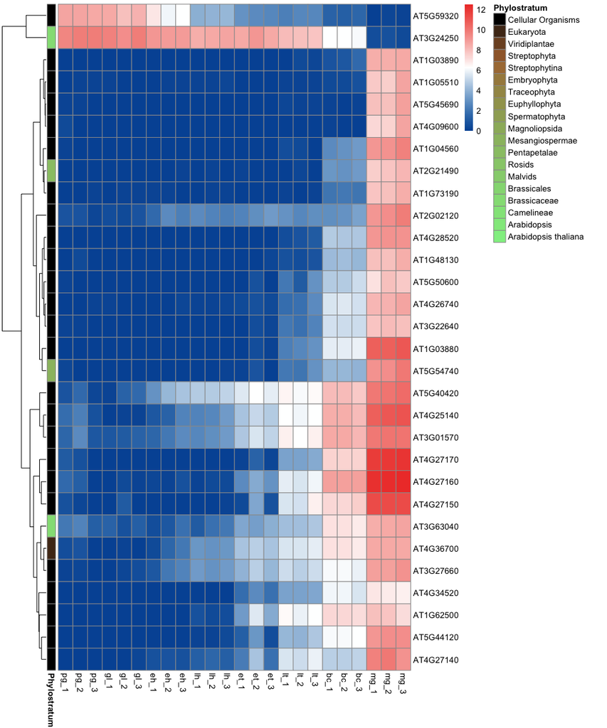

```r
myTAI::plot_gene_heatmap(example_phyex_set, cluster_rows = TRUE, show_reps=TRUE, top_p=0.005, std=FALSE, show_gene_ids=TRUE)
```

#### Dimension reduction

##### At the gene level

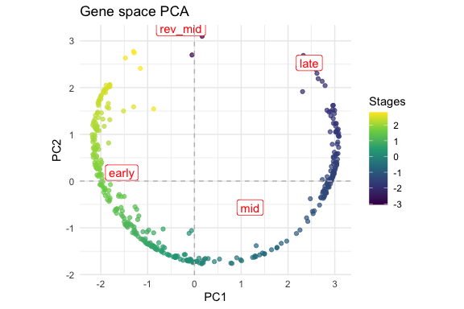

```r
myTAI::plot_gene_space(example_phyex_set)
```

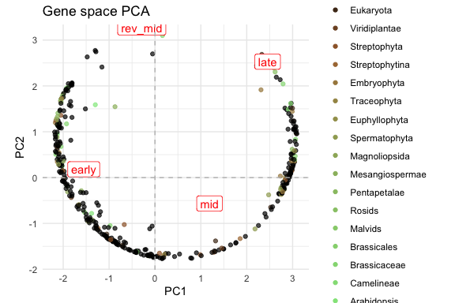

```r
myTAI::plot_gene_space(example_phyex_set,colour_by = "strata")
```

##### At the sample level

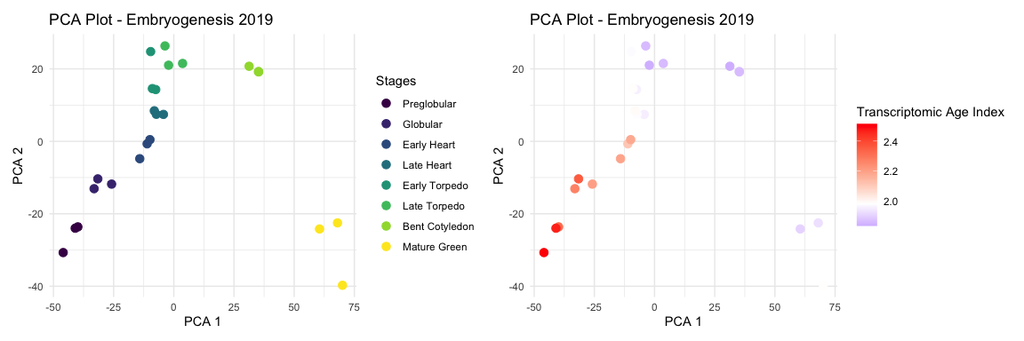

```r
myTAI::plot_sample_space(example_phyex_set) | myTAI::plot_sample_space(example_phyex_set, colour_by = "TXI")
```

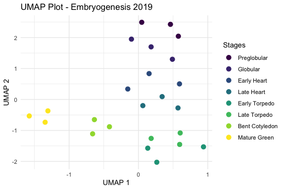

```r
# we can even do a UMAP
myTAI::plot_sample_space(example_phyex_set, method = "UMAP")
```

#### Inspecting mean-variance relationship

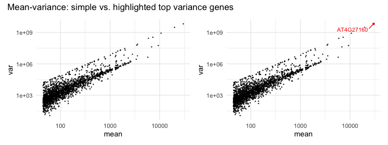

```r
# highlighting top variance genes
top_var_genes <- myTAI::genes_top_variance(example_phyex_set, top_p = 0.9995)
p1 <- myTAI::plot_mean_var(example_phyex_set)
p2 <- myTAI::plot_mean_var(example_phyex_set,
                     highlight_genes = top_var_genes)

p1 + p2 + plot_annotation(title = "Mean-variance: simple vs. highlighted top variance genes")
```

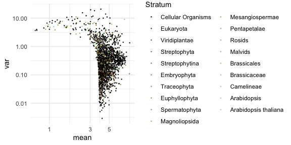

```r
# with log transform and colouring by phylostratum
myTAI::plot_mean_var(example_phyex_set |> myTAI::tf(log1p),
                     colour_by = "strata") +
  ggplot2::guides(colour = guide_legend(ncol=2))
```

#### Individual gene expression profiles

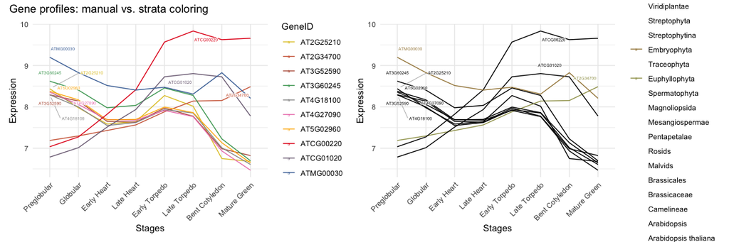

```r
# side by side: manual coloring vs strata coloring
p1 <- myTAI::plot_gene_profiles(example_phyex_set, max_genes = 10, colour_by = "manual")
p2 <- myTAI::plot_gene_profiles(example_phyex_set, max_genes = 10, colour_by = "strata")

p1 + p2 + plot_annotation(title = "Gene profiles: manual vs. strata coloring")
```

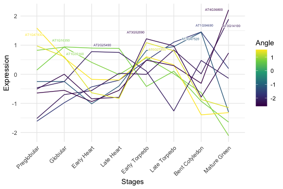

```r
# stage colouring with standardized log transformation
myTAI::plot_gene_profiles(example_phyex_set, max_genes = 10,
                          transformation = "std_log", colour_by = "stage")
```

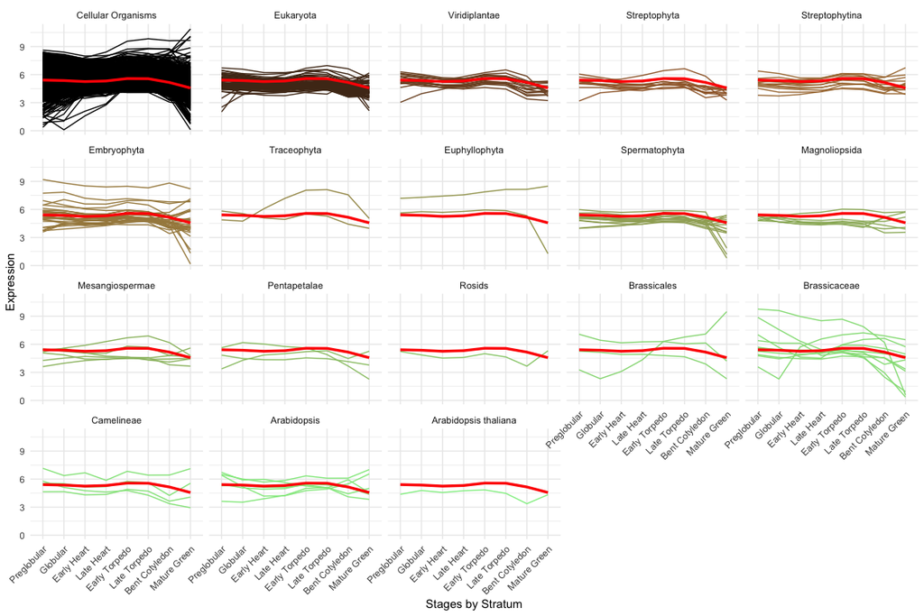

```r
# faceted by phylostratum
myTAI::plot_gene_profiles(example_phyex_set, max_genes = 1000,
                          colour_by = "strata", facet_by_strata = TRUE, show_set_mean = TRUE,
                          show_labels = FALSE)
```

These plots are examples of plots that `myTAIv2` can generate. To check out the functions, use `?` before the function (i.e. `?myTAI::plot_mean_var()`.

You can also find a list of plotting functions in `Reference`.

### Single cell RNA-seq data

Most of the plotting functions shown above also apply for single cell RNA-seq data, as long as it is a `ScPhyloExpressionSet` object.

Let’s create an example single-cell dataset and explore the plotting capabilities:

```r
# Load example single-cell data
data(example_phyex_set_sc)
```

```r
example_phyex_set_sc
```

```
## PhyloExpressionSet object
## Class: myTAI::ScPhyloExpressionSet
## Name: Single Cell Example
## Species: Example Species
## Index type: TXI
## Cell Type : TypeA, TypeB, TypeC
## Number of genes: 99
## Number of cell type : 3
## Number of phylostrata: 10
## Total cells: 200
## Cells per type:
##
## TypeA TypeB TypeC
##    70    66    64
## Available metadata:
##   groups: TypeA, TypeB, TypeC
##   day: Day1, Day3, Day5, Day7
##   condition: Control, Treatment
##   batch: Batch1, Batch2, Batch3
```

```r
# Check available identities
cat("Available identities for plotting:\n")
```

```
## Available identities for plotting:
```

```r
print(example_phyex_set_sc@available_idents)
```

```
## [1] "groups"    "day"       "condition" "batch"
```

```r
# Set up custom color schemes for better visualization
day_colors <- c("Day1" = "#3498db", "Day3" = "#2980b9", "Day5" = "#1f4e79", "Day7" = "#0d2a42")
condition_colors <- c("Control" = "#27ae60", "Treatment" = "#e74c3c")
group_colors <- c("TypeA" = "#e74c3c", "TypeB" = "#f39c12", "TypeC" = "#9b59b6")

example_phyex_set_sc@idents_colours[["day"]] <- day_colors
example_phyex_set_sc@idents_colours[["condition"]] <- condition_colors
example_phyex_set_sc@idents_colours[["groups"]] <- group_colors
```